# Problem Set 04: Solutions

ANSWERS

2019

```r
library(dplyr)
library(ggplot2)
library(readr)
library(moderndive)
```

```r
trump <- read_csv("https://docs.google.com/spreadsheets/d/e/2PACX-1vT8qHdvTPaRc62hU94ShBcSh04HP3c11b6XZIPMiUDGuwPtifpP7QhHdSHS2YgTRMRTgfUmBYq-L3ZT/pub?gid=1217616678&single=true&output=csv")
```

Take a moment to look at the data in the viewer or by using `glimpse()`. The explanatory variables include:

- `hs_ed` - the percentage of the adults in the region with a high school education.
- `poverty`- the percentage of the “white” households in the region in poverty.
- `non_white`- the percentage of humans in a region that identify as a person of color.

The outcome variable `trump_support` is the percentage of votes for Trump in 2016 in each region.

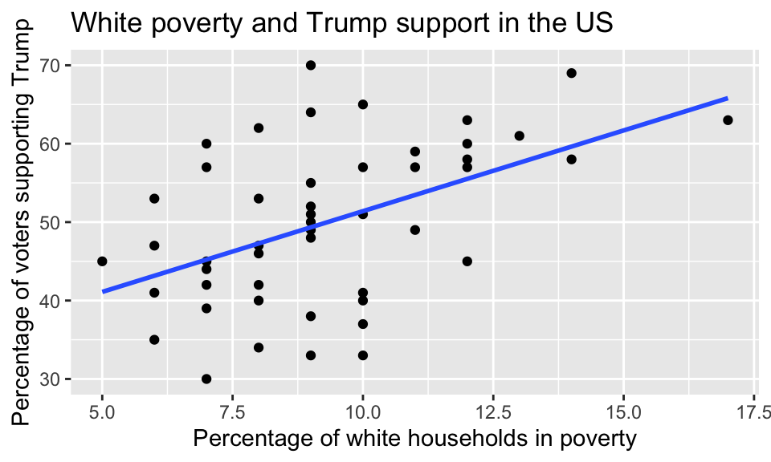

```r
ggplot(data = trump, aes(y = trump_support, x = poverty)) +
  geom_point() +
  geom_smooth(method = "lm", se = FALSE) +
  labs(x = "Percentage of white households in poverty",
       y = "Percentage of voters supporting Trump",
       title = "White poverty and Trump support in the US")
```

# QUESTION 1

Does the relationship appear to be positive or negative? Does it look to be reasonably linear?

**Answer:** Positive, reasonably linear

## The correlation coefficient (r)

```r
trump %>%
  summarise(r = cor(trump_support, poverty))
```

| r |
| --- |
| 0.4864114 |

## Running a linear regression model

In R we can fit a linear regression model (a regression line), like so:

```r
poverty_mod <- lm(trump_support ~ poverty, data = trump)
```

## Get the regression table

```r
get_regression_table(poverty_mod)
```

| term | estimate | std_error | statistic | p_value | lower_ci | upper_ci |
| --- | --- | --- | --- | --- | --- | --- |
| intercept | 30.806 | 5.223 | 5.898 | 0 | 20.293 | 41.320 |
| poverty | 2.059 | 0.545 | 3.776 | 0 | 0.961 | 3.157 |

We can interpret the `intercept` and `poverty` slope like so:

- When the poverty level is 0, the predicted average Trump support is 30.81%
- For every increase in poverty level of 1 percentage point, there is an **associated increase** in Trump support of 2.059 percentage points.

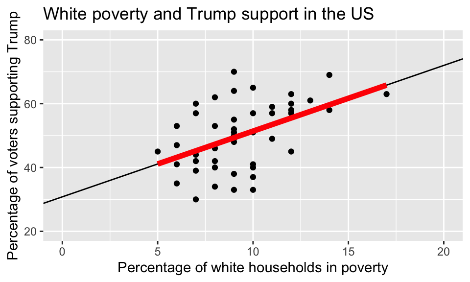

# QUESTION 2

We found a positive correlation coefficient. Is it reasonable for us to conclude that social policies that increase white poverty will **cause** an increase in Trump support? Explain why or why not?

**Answer:** No- correlation does not necessarily imply causation.

## Making predictions

Based on the R output of our model, the following is our least squares regression line for the linear model:

$\widehat{trump\_support} = 30.806 + 2.059 \times poverty$

```r
y_hat = 30.8064 + 2.0591 * 15
y_hat
```

```
## [1] 61.6929
```

# QUESTION 3

What percent of Trump support would you expect at a value of 6% white poverty?

**Answer:**

```r
y_hat = 30.8064 + 2.0591 * 6
y_hat
```

```
## [1] 43.161
```

# QUESTION 4

Do you think it is a good idea to predict Trump support at 85% white poverty, based on this regression equation? Explain your reasoning.

**Answer:** No, that would be extrapolation. Our data does not include values that high for `poverty` variable

## Residuals

Recall that model residuals are the difference between the **observed values in your data set** and the **values predicted by the line**:

$\text{residual} = y - \hat{y}$

For instance, below, one data point is highlighted in blue…the residual is the difference between the y value of the **data point** (here 69), and the y value **predicted** by the line (roughly 59). Here the residual is roughly 10 ($69 - 59 = 10$). The regression equation has under-estimated Trump support, compared to this data point.

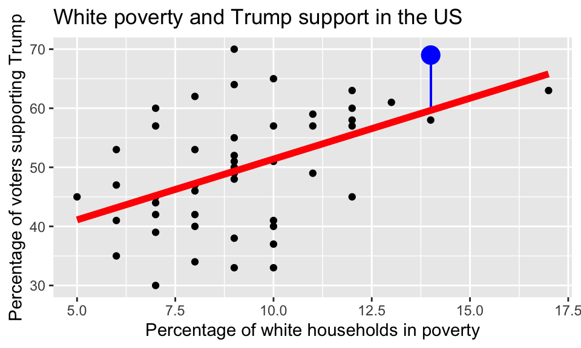

## Put your skills to practice independently!

Use the same `trump` data set for the following questions:

# QUESTION 5

Generate a scatterplot with a best-fitting line with `non_white` as the explanatory variable, and `trump_support` as the response. Be sure to include an informative title and axis labels to your plot. This will help contextualize it.

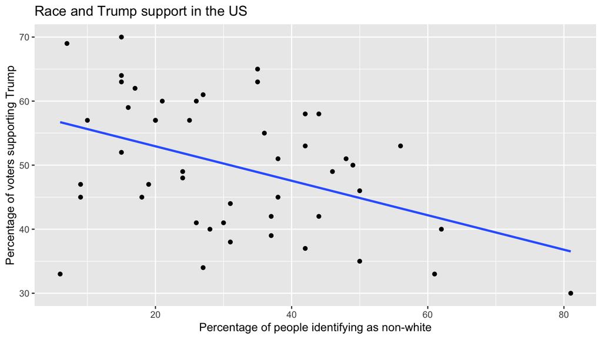

```r
ggplot(data = trump, aes(y = trump_support, x = non_white)) +
  geom_point() +
  geom_smooth(method = "lm", se = FALSE) +
  labs(x = "Percentage of people identifying as non-white",
       y = "Percentage of voters supporting Trump",
       title = "Race and Trump support in the US")
```

# QUESTION 6

Do you expect the correlation coefficient (for `non_white` and `trump_support`) to be positive or negative? Write code chunk testing your prediction (it is OK if your expectation was wrong!).

**Answer:** negative (whatever you guess is OK…this is just to stimulate thought)

```r
trump %>%
  summarise(r = cor(trump_support, non_white))
```

| r |
| --- |
| -0.4250604 |

# QUESTION 7

Run a linear regression using `non_white` as the **explanatory** variable, and `trump_support` as the **outcome** variable. Interpret the Intercept and slope estimates.

```r
wh_mod <- lm(trump_support ~ non_white, data = trump)
get_regression_table(wh_mod)
```

| term | estimate | std_error | statistic | p_value | lower_ci | upper_ci |
| --- | --- | --- | --- | --- | --- | --- |
| intercept | 58.328 | 2.976 | 19.601 | 0.000 | 52.338 | 64.318 |
| non_white | -0.269 | 0.084 | -3.185 | 0.003 | -0.439 | -0.099 |

**Answer:**

When there is **0% of non-white individuals** in a voting area, the model predicts an **average of 58% Trump Support.**

When the percentage of non-white individuals in a voting area goes up by one percentage unit, the Trump support goes **down by 0.269 percentage points**.

# QUESTION 8

Make a numerical prediction for the level of trump support for a region that has 70% of humans that identify as a person of color. In other words, use **math** not a visual prediction.

```r
58.328 + (-0.269 * 70)
```

```
## [1] 39.498
```

**Answer:** 39%

# QUESTION 9

Based on the evidence you have so far (scatterplots and correlation coefficients), which of the explanatory variables we have considered (`non_white` or `poverty`) seems to be a better explanatory variable of Trump support? Explain.

**Answer:** **Poverty seems to be a slightly better predictor**. The scatterplots look quite similar in the spread of points around the line. The correlation coefficients are also pretty similar, but the `poverty` model r is slightly larger (0.48) than the `non_white` r (-0.42).

# QUESTION 10

If Representative Ocasio-Cortez saw the regression line and not the actual data:

**A.** What would her prediction of Trump support be for a region in which 61% of the people identify as non-white?

**B.** Would her prediction be an overestimate or an underestimate (compared to the observed data), and by how much?

**C.** In other words, what is the residual for this prediction?

**NOTE: For 10a and 10b, you can either answer using a “visual estimate” of the model’s prediction and residual (based on the scatterplot with the regression line overlayed that they created to answer question 5), or precisely (by plugging 61% into the regression equation themselves, or using the `get_regression_points` function).**

**Because you may answer the question in either manner, approximately correct values for 10a and 10b are okay. So, for 10a, answers in the range of 41-43% should be considered correct, and for 10b, answers in the range of 7-10% should be considered correct.**

**For 10c however, you should give their answer precisely, e.g., use the `get_regression_points` function.**

```r
get_regression_points(wh_mod) %>%
  filter(non_white == 61)
```

| ID | trump_support | non_white | trump_support_hat | residual |
| --- | --- | --- | --- | --- |
| 2 | 33 | 61 | 41.912 | -8.912 |

**Answers:**

**A** The model predicts approximately 41% Trump support (41.912% to be precise)

**B** The observed value at `non_white` (ID 2) was 33% Trump support. Thus the model overpredicted, by approximately 8%.

**C** The residual is (observed - predicted)…33 - 41.912 = -8.912 (OK if they are a little off due to rounding, and OK if they say 8.9% instead of negative 8.9%)